# Exploratory data analysis and Modelization

# EXPLORATORY DATA ANALYSIS

## 1. Data preparation

The data have been downloaded from the website and a basic cleaning has been done in the preparation step. Due to the size of the dataset, which is 2.5 Gb for 3 months of data, a sample is obtained in order to explore the data more efficiently.

The preparation of the data include:

- Remove the N/A values of the data
- After check for the variables and its meaning, extract the values among its (logical) range:
  - fare > 0
  - trip distance > 0
  - extra charges >= 0
  - tolls >= 0
  - total amount > 0
  - improvement surchage == 0.3
  - passesngers >= 0

Load the libraries.

```r
library(dplyr)
library(reshape2)
library(magrittr)
library(latticeExtra)
library(zoo)
library(ggplot2)
library(raster)
library(sf)
library(RColorBrewer)
library(lubridate)
```

### 1. Read the taxi data

The sample data is read after the preparation step which includes a basic cleaning and preparation of the data.

```r
data  <-  read.csv("data/taxi_sample_data.csv")
```

### 2. Load the taxi zone data

Besides the records of trips, the website includes a .csv with the taxi zones in New York

```r
zones <-  read.csv("data/taxi_zones.csv")
```

### 3. Plot the area of the analysis

#### TCL zones

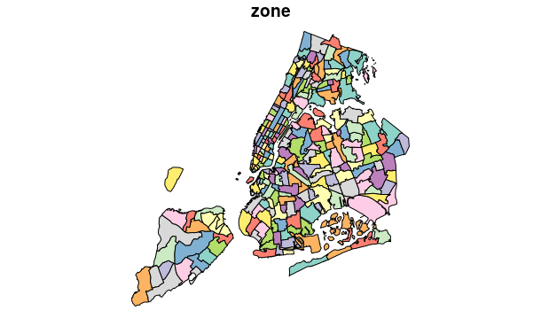

```r
plot(spZones["zone"])
```

From the shp file, we have also information about boroughs:

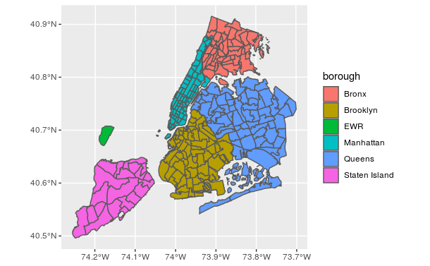

```r
borough <-  ggplot() + geom_sf(data=spZones, aes(fill = borough))
borough
```

There is also information about the kind of service area in the .csv

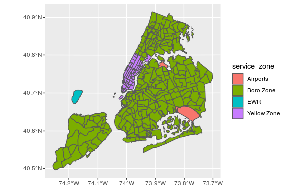

```r
a <- merge(spZones, zones[,c(1,4)], by='LocationID')
service <-  ggplot() + geom_sf(data=a, aes(fill = service_zone))
service
```

### 4. Make a summary of the dataset for a first analysis.

```r
summary(data)
```

```
    VendorID              tpep_pickup_datetime         tpep_dropoff_datetime passenger_count trip_distance
 Min.   :1.000   2017-06-28 20:31:05:    3     2017-03-18 03:32:29:    3     Min.   :1.000   Min.   : 0.510
 1st Qu.:1.000   2017-11-27 20:08:58:    3     2017-06-05 19:30:40:    3     1st Qu.:1.000   1st Qu.: 1.200
 Median :2.000   2017-03-01 18:04:24:    2     2017-03-01 18:11:50:    2     Median :1.000   Median : 1.900
 Mean   :1.549   2017-03-01 19:07:32:    2     2017-03-01 19:20:12:    2     Mean   :1.619   Mean   : 2.942
 3rd Qu.:2.000   2017-03-01 19:38:59:    2     2017-03-01 19:33:17:    2     3rd Qu.:2.000   3rd Qu.: 3.500
 Max.   :2.000   2017-03-01 21:44:09:    2     2017-03-01 20:13:47:    2     Max.   :6.000   Max.   :52.200
                 (Other)            :43751     (Other)            :43751
   RatecodeID    store_and_fwd_flag  PULocationID    DOLocationID    payment_type  fare_amount         extra
 Min.   :1.000   N:43598            Min.   :  4.0   Min.   :  3.0   Min.   :1     Min.   :  2.50   Min.   :0.5000
 1st Qu.:1.000   Y:  167            1st Qu.:113.0   1st Qu.:100.0   1st Qu.:1     1st Qu.:  7.00   1st Qu.:0.5000
 Median :1.000                      Median :161.0   Median :161.0   Median :1     Median : 10.00   Median :0.5000
 Mean   :1.002                      Mean   :161.5   Mean   :158.4   Mean   :1     Mean   : 12.71   Mean   :0.6649
 3rd Qu.:1.000                      3rd Qu.:231.0   3rd Qu.:234.0   3rd Qu.:1     3rd Qu.: 15.00   3rd Qu.:1.0000
 Max.   :4.000                      Max.   :265.0   Max.   :265.0   Max.   :1     Max.   :245.00   Max.   :1.0000

    mta_tax      tip_amount       tolls_amount     improvement_surcharge  total_amount
 Min.   :0.5   Min.   :  0.010   Min.   : 0.0000   Min.   :0.3           Min.   :  5.31
 1st Qu.:0.5   1st Qu.:  1.550   1st Qu.: 0.0000   1st Qu.:0.3           1st Qu.: 10.30
 Median :0.5   Median :  2.150   Median : 0.0000   Median :0.3           Median : 13.56
 Mean   :0.5   Mean   :  2.765   Mean   : 0.2123   Mean   :0.3           Mean   : 17.16
 3rd Qu.:0.5   3rd Qu.:  3.200   3rd Qu.: 0.0000   3rd Qu.:0.3           3rd Qu.: 19.80
 Max.   :0.5   Max.   :425.470   Max.   :37.7600   Max.   :0.3           Max.   :445.27
```

Main characteristics seen in summary are related to the numeric variables, where maximum values are much higher than the mean or the median: total amount, tip amount, tolls, fare amount etc. This could be related to outliers or skewed distributions of the data.

## 2. Numeric variables

We will now explore the numeric variables and look for the main characteristics and data distributions.

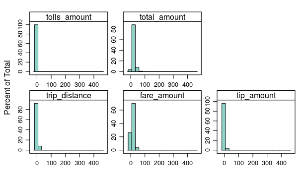

```r
# extract from the dataset the numeric variables
df  <-  data[, c(5,11,14,15,17)]
df  <-  melt(df)
# Theme characteristics for plots.
myTheme  <- custom.theme(pch=20, cex=0.5)
myTheme$strip.background$col  <- "white"
# Frequency of data in each variable
histogram(~value|variable, data=df, par.settings=myTheme, xlab=" ", scales='free')
```

The boxplot can also help to see the data distribution. There are some data records which present very high values for the numeric variables. So the distribution does not seem to be normal.

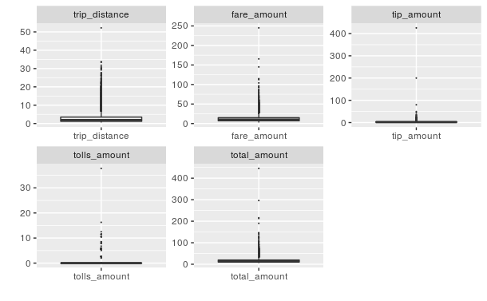

```r
ggplot(df, aes(x=variable,y=value)) +
    geom_boxplot(aes(fill=value),outlier.size = 0.1) +
    labs(x=" ", y=" ") +
     facet_wrap(~ variable, scales='free')
```

We include new conditions for the numeric variables. The total, *fare* and *tip amount* have extremely large values.

We also check that some records have lower fares than tips, so that values are removed.

Aditionally, the tip should be at least 10% of the fare and we also consider only tips below 30% of the fare. The idea is to recommend a tip depending on other variables, but a tip above 30% cannot be recommended.

Remove records with fares lower than tips and tips lower than 10% and above 30%:

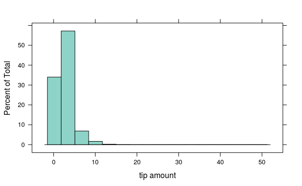

```r
data  <- data[data$fare_amount > data$tip_amount,]
data  <-  data[data$tip_amount > 0.1*data$fare_amount,]
data  <-  data[data$tip_amount < 0.3*data$fare_amount,]
histogram(data$tip_amount, par.settings=myTheme, xlab="tip amount")
```

We can have a look on the tip amount as a % of the fare amount.

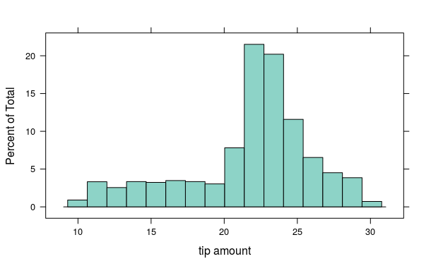

```r
histogram((data$tip_amount/data$fare_amount)*100, par.settings=myTheme, xlab="tip amount")
```

Most of the tips are between the 20 and 25% of the fare amount.

### 1. Trip time duration

Another numeric variable that could be relevant is the duration of each trip. We can calculate this variable from the pick up and drop off time.

Time stamp are loaded as factor. Translate into daytime:

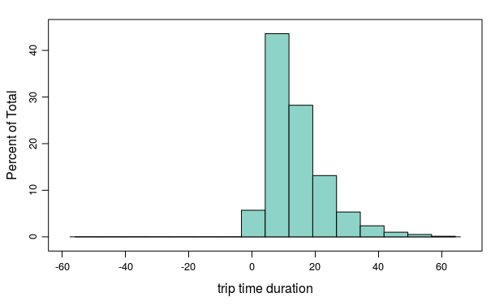

```r
data$tpep_pickup_datetime <- as.POSIXct(as.character(data$tpep_pickup_datetime), tz = "GMT", format="%Y-%m-%d %H:%M:%S")
data$tpep_dropoff_datetime <- as.POSIXct(as.character(data$tpep_dropoff_datetime), tz = "GMT",format="%Y-%m-%d %H:%M:%S")
## transform to NY time zone
data$tpep_pickup_datetime <- with_tz(data$tpep_pickup_datetime, tzone = "America/New_York")
data$tpep_dropoff_datetime <- with_tz(data$tpep_dropoff_datetime, tzone = "America/New_York")
## new column with the differences:
## it takes few minutes
data$trip_timelength  <- apply(data, 1, FUN=function(x) difftime(x[3], x[2]))
# Plot the new variable
histogram(data$trip_timelength, par.settings=myTheme, xlab="trip time duration", scales='free')
```

The data have negative values that should be removed

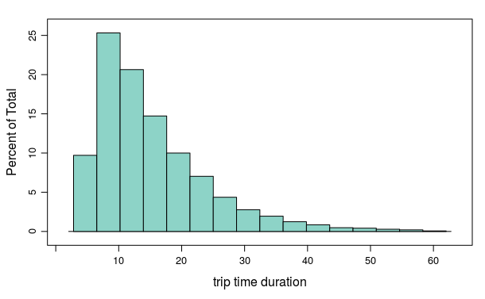

```r
data  <- data[data[,"trip_timelength" ] > 5,]
df  <-  data[, c(5,11,14,15,17,18)]
df  <-  melt(df)
histogram(data$trip_timelength, par.settings=myTheme, xlab="trip time duration", scales='free')
```

We can now plot all the numeric variables together again and we will see how the largest values in the fare amount have been removed at the same time that the negative trip duration. The boxplots show us the general statistics of the data, with the median value and the range of the quantiles; we can as well add the density functions in a violin plot, which helps with the shape of the data distributions when it is different from the normal.

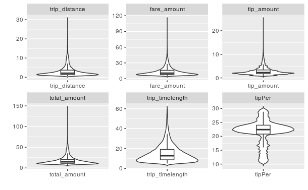

```r
# extract from the dataset the numeric variables
df  <-  data[, c(5,11,14,17,18)]
df$tipPer <- df[,3]/df[,2]*100
df  <-  melt(df)
ggplot(df, aes(x=variable,y=value)) +
    geom_violin(trim=FALSE)+
    geom_boxplot(width=0.2, outlier.shape=NA, aes(fill=value)) +
    labs(x=" ", y=" ") +
     facet_wrap(~ variable, scales='free')
```

### 2. Numerical variables relationships

We can have a look on the scatterplots of the numerical variables: a linear relationship is seen, but with some stratified characteristics. If we have a look on the tip amount at the center of the scatterplot matrix, we can see that there are some values of constant ‘tip amount’ independently of the fare amount.

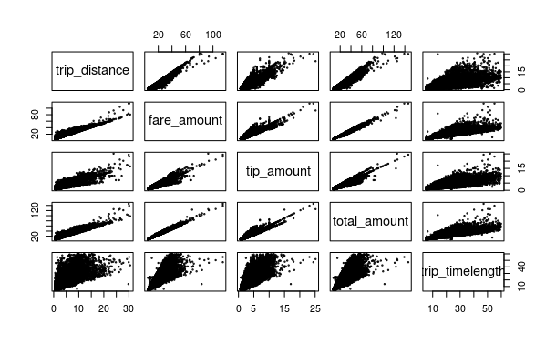

```r
pairs(data[,c(5,11,14,17,18)], cex=0.3)
```

Once the general linear relationship is seen, we can remove some of the outliers.

```r
## First, calculate the quantiles and the IQR in the numeric variables:
quant  <-  function(x) {
    q  <-  quantile(x, probs=c(.25 ,.75))
    iqr  <- IQR(x)

    up  <-  q[2] + 1.5 *iqr
    down  <- q[1] - 1.5 *iqr
    c  <- c(up,down)
    c
}
## apply this function to the 5 relevant numeric variables:
var  <-  list("trip_distance","fare_amount","tip_amount","tolls_amount","total_amount")
q  <- lapply(var, FUN=function(x) quant(data[,x]))
names(q) <- var
## filter the dataset with these conditions:
subsetq <-  function(x) {
    for (i in 1:length(var)) {
        out  <- subset(x, x[var[[i]]] < (q[[i]][1]) & x[var[[i]]] > (q[[i]][2]))

    }
    out
}
data  <- subsetq(data)
```

If we represent again the data:

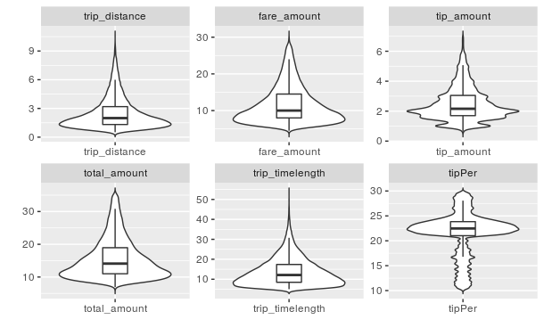

```r
# extract from the dataset the numeric variables
df  <-  data[, c(5,11,14,17,18)]
df$tipPer <- df[,3]/df[,2]*100
df  <-  melt(df)
ggplot(df, aes(x=variable,y=value)) +
    geom_violin(trim=FALSE)+
    geom_boxplot(width=0.2, outlier.shape=NA, aes(fill=value)) +
    labs(x=" ", y=" ") +
     facet_wrap(~ variable, scales='free')
```

### 3. Hour off pick up or drop off

Another variable that could be relevant is the time of pick up or drop off the taxi. Create new columns with the time (hour) of the pick up and drop off.

```r
d1 <- as.character(data$tpep_pickup_datetime)
d2 <- as.character(data$tpep_dropoff_datetime)
data$t_pu <- hour(data$tpep_pickup_datetime)
data$t_do <- hour(data$tpep_dropoff_datetime)
```

Plot the frequency of records by hour of bick up.

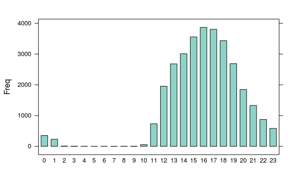

```r
df  <- data[, c("tip_amount","t_pu", "t_do")]
barchart(table(data$t_pu), par.settings=myTheme, xlab=" ", horizontal=FALSE)
```

It can be seen that there is little amount of data between 2 to 9 a.m compared to the rest of the day. Less taxi trips are made on overnight hours. We see if there is any different on the tip depending on the pick up hour:

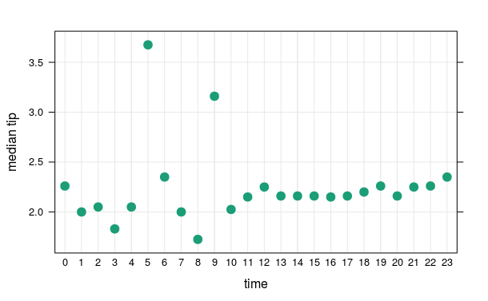

```r
df <- df %>%
group_by(t_pu) %>%
    summarise(m = median(tip_amount))%>%
    as.data.frame()

dotplot(m~as.factor(t_pu), data=df, pch=20, grid=TRUE, cex=2, ylab='median tip', xlab='time', par.settings=myTheme)
```

Between 0 and 8 in the morning, the median tip amount behaves different, but we should be **careful**, due to the fact that it is the beriod with less records and the conclusions might not be representative.

The median value of tip (%) is representd for each hour. Again, it is difficult to find a conclusion due to the lack of data in the range of 0 to 9 hours, but highest value is found at 9 a.m and a trend for higher values between 11 to 12.

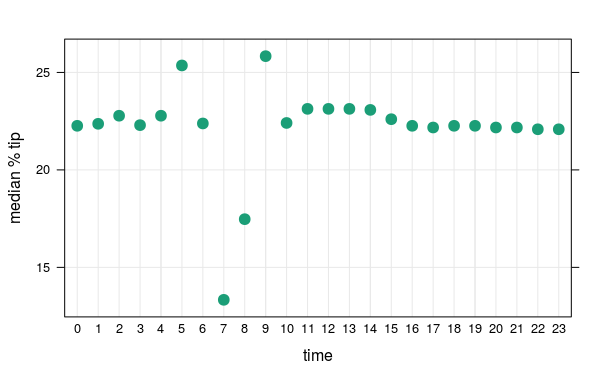

```r
df  <- data[ ,c("t_pu", "t_do")]
df$tipPer <- data[,14]/data[,11]*100
df <- df %>%
group_by(t_pu) %>%
    summarise(m = median(tipPer))%>%
    as.data.frame()

dotplot(m~as.factor(t_pu), data=df, pch=20, grid=TRUE, cex=2, ylab='median % tip', xlab='time', par.settings=myTheme)
```

## 3. Categorical variables

After having seen the numeric variables of the dataset, we take care of the categorical variables that it includes.

- Payment type: only card record is found

```r
which(data$payment_type != 1) # records of payments different than 1
```

```
integer(0)
```

- RateCodeID: there is only code number 1

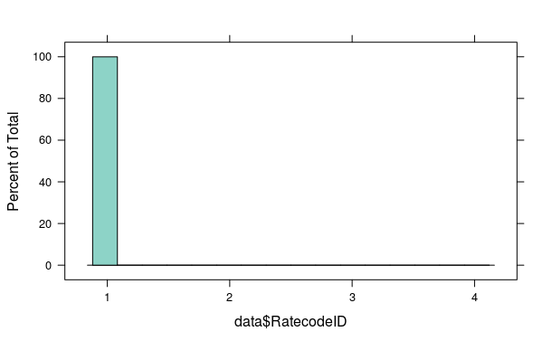

```r
histogram(data$RatecodeID, par.settings=myTheme)
```

```r
which(data$RatecodID != 1)
```

```
integer(0)
```